# Statistiques APAAD - 10/05/2020

[figure not shown]

# 1 Profils des femmes

Les données présentement étudiées concernent 1298 femmes.

## 1.1 Âge

| Transfert | Moyenne âge | Minimum âge | Maximum âge | Écart-type âge | Nombre de femmes | Proportion | Nombre de femmes âge 35+ | Proportion de femmes âge 35+ |
| --- | --- | --- | --- | --- | --- | --- | --- | --- |
| Anténatal | 32.71 | 20 | 45 | 4.08 | 217 | 16.72 % | 74 | 34.1 % |
| Per-partum | 32.22 | 22 | 44 | 4.39 | 147 | 11.33 % | 40 | 27.21 % |
| Post-partum maternel | 30.71 | 24 | 41 | 4.45 | 14 | 1.08 % | 2 | 14.29 % |
| Post-partum néonatal | 33.09 | 27 | 45 | 6.16 | 11 | 0.85 % | 3 | 27.27 % |
| Aucun | 32.39 | 16 | 45 | 4.53 | 909 | 70.03 % | 295 | 32.45 % |
| Total | 32.41 | 16 | 45 | 4.46 | 1298 | 100 % | 414 | 31.9 % |

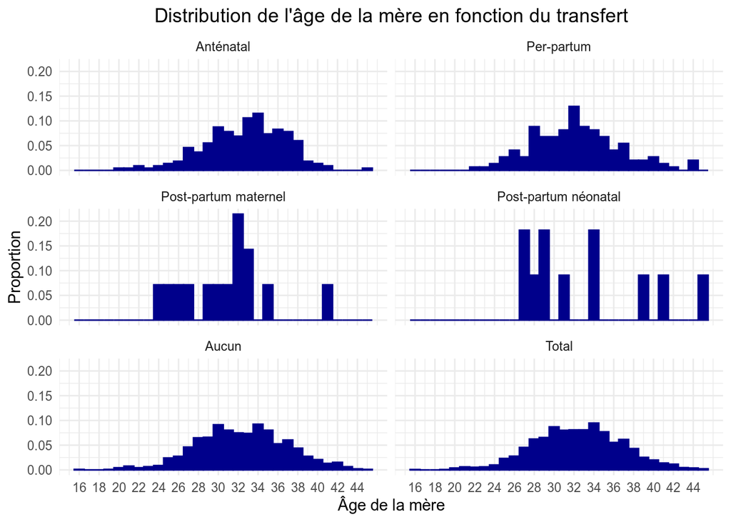

## 1.2 Parité

### 1.2.1 Parités sur l’ensemble de la population

| Parité | Nombre | Proportion |
| --- | --- | --- |
| 1 | 470 | 36.21 % |
| 2 | 446 | 34.36 % |
| 3 | 228 | 17.57 % |
| 4 | 91 | 7.01 % |
| 5 | 42 | 3.24 % |
| 6 | 9 | 0.69 % |
| 7 | 4 | 0.31 % |
| 8 | 5 | 0.39 % |
| 9 | 1 | 0.08 % |
| 10 | 1 | 0.08 % |
| 11 | 1 | 0.08 % |

### 1.2.2 Parité selon le type de transfert

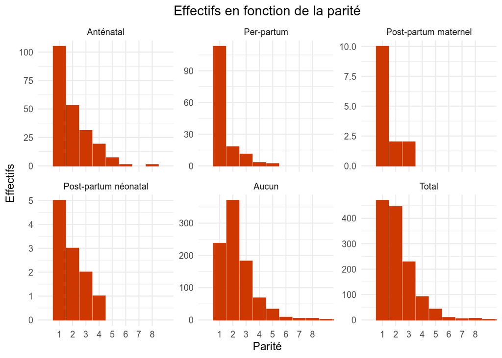

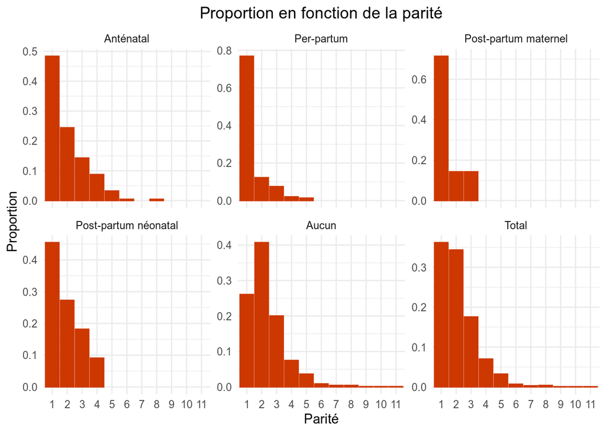

### 1.2.3 Primiparité

| Transfert | Parité | Nombre | Proportion |
| --- | --- | --- | --- |
| Anténatal | Primipares | 105 | 48.39 % |
| Anténatal | Multipares | 112 | 51.61 % |
| Per-partum | Primipares | 113 | 76.87 % |
| Per-partum | Multipares | 34 | 23.13 % |
| Post-partum maternel | Primipares | 10 | 71.43 % |
| Post-partum maternel | Multipares | 4 | 28.57 % |
| Post-partum néonatal | Primipares | 5 | 45.45 % |
| Post-partum néonatal | Multipares | 6 | 54.55 % |
| Aucun | Primipares | 237 | 26.07 % |
| Aucun | Multipares | 672 | 73.93 % |
| Total | Primipares | 470 | 36.21 % |
| Total | Multipares | 828 | 63.79 % |

#### 1.2.3.1 Risque relatif de transfert des primipares par rapport aux multipares

- Transfert anténatal : RR = 1.65 et IC95%(RR) = [1.3;2.1]
- Transfert pre-partum : RR = 5.86 et IC95%(RR) = [4.06;8.45]
- Transfert post-partum maternel : RR = 3.23 et IC95%(RR) = [1.2;8.68]
- Transfert post-partum néonatal : RR = 1.76 et IC95%(RR) = [0.62;4.99]

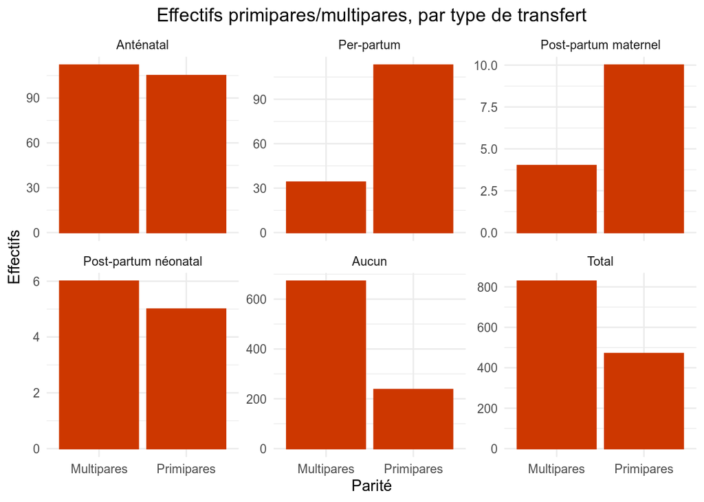

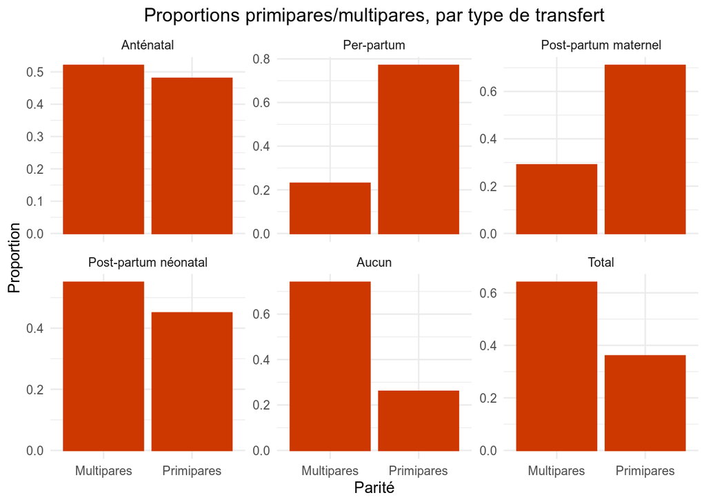

### 1.2.4 Femmes ayant 5 enfants ou plus

[output not shown]

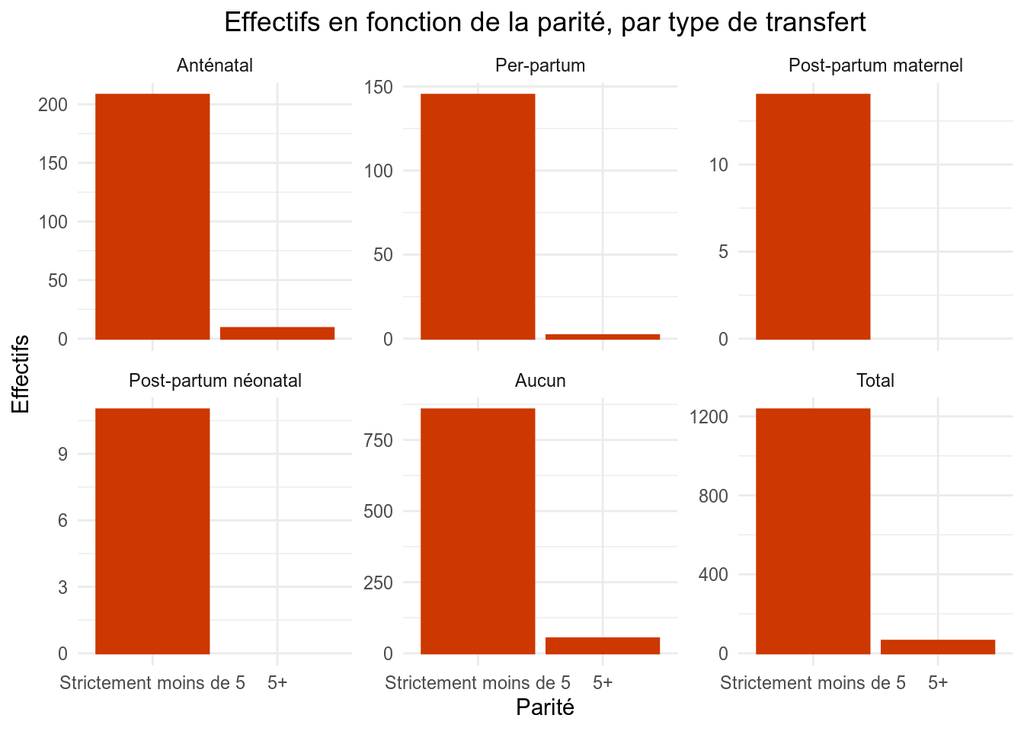

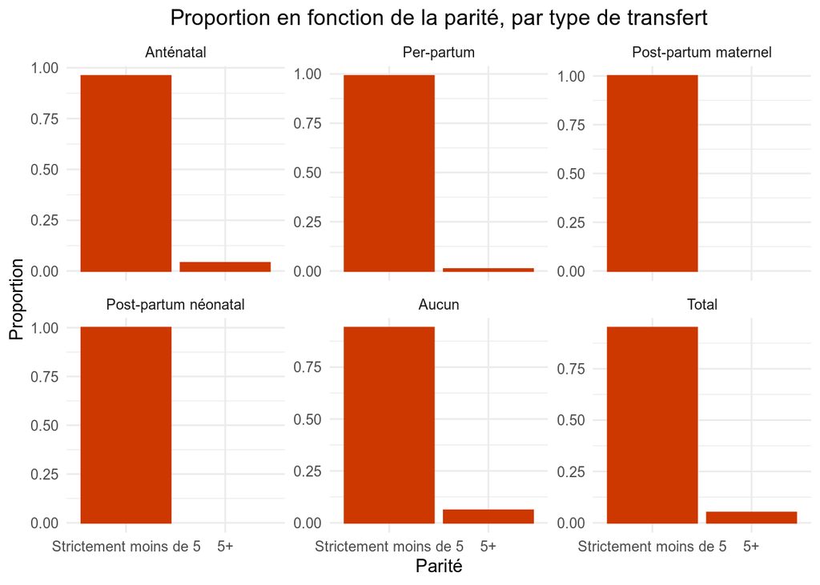

## 1.3 Âge gestationnel

### 1.3.1 Population complète

| Âge gestationnel | Nombre | Proportion |
| --- | --- | --- |
| 0 | 2 | 0.15 % |
| 8 | 1 | 0.08 % |
| 20 | 1 | 0.08 % |
| 23 | 1 | 0.08 % |
| 24 | 1 | 0.08 % |
| 30 | 1 | 0.08 % |
| 31 | 1 | 0.08 % |
| 32 | 1 | 0.08 % |
| 34 | 5 | 0.39 % |
| 35 | 7 | 0.54 % |
| 36 | 6 | 0.46 % |
| 37 | 38 | 2.93 % |
| 38 | 105 | 8.09 % |
| 39 | 320 | 24.65 % |
| 40 | 472 | 36.36 % |
| 41 | 307 | 23.65 % |
| 42 | 26 | 2 % |
| 49 | 1 | 0.08 % |
| NA | 2 | 0.15 % |

### 1.3.2 Âge gestationnel selon le type de transfert

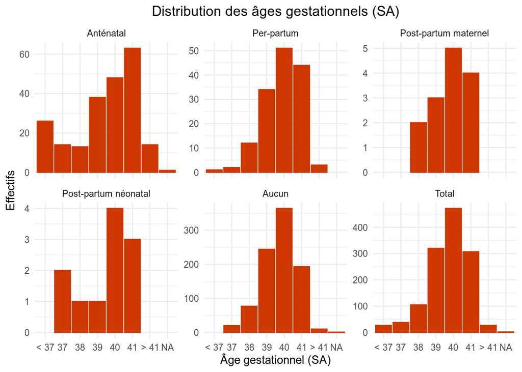

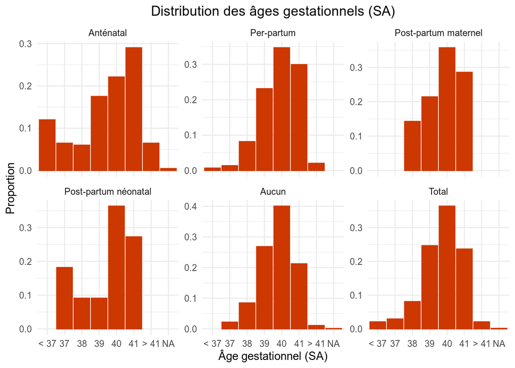

## 1.4 Type de suivi

| Transfert | Type de suivi | Nombre | Proportion |
| --- | --- | --- | --- |
| Anténatal | A | 135 | 62.21 % |
| Anténatal | A1 | 41 | 18.89 % |
| Anténatal | A2 | 29 | 13.36 % |
| Anténatal | B | 12 | 5.53 % |
| Per-partum | A | 115 | 78.23 % |
| Per-partum | A1 | 23 | 15.65 % |
| Per-partum | A2 | 6 | 4.08 % |
| Per-partum | B | 3 | 2.04 % |
| Post-partum maternel | A | 13 | 92.86 % |
| Post-partum maternel | A1 | 1 | 7.14 % |
| Post-partum néonatal | A | 8 | 72.73 % |
| Post-partum néonatal | A1 | 2 | 18.18 % |
| Post-partum néonatal | A2 | 1 | 9.09 % |
| Aucun | A | 786 | 86.47 % |
| Aucun | A1 | 99 | 10.89 % |
| Aucun | A2 | 21 | 2.31 % |
| Aucun | B | 3 | 0.33 % |
| Total | A | 1057 | 81.43 % |
| Total | A1 | 166 | 12.79 % |
| Total | A2 | 57 | 4.39 % |
| Total | B | 18 | 1.39 % |

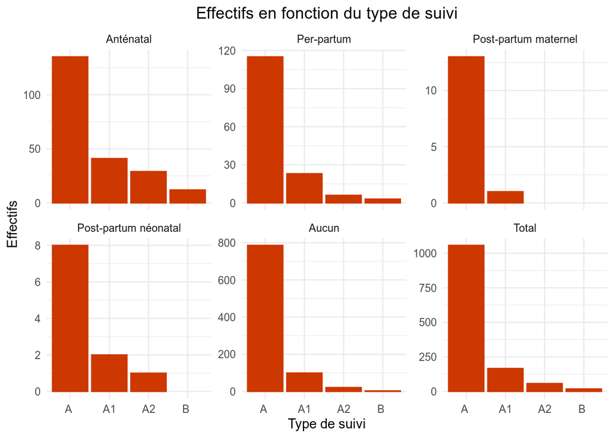

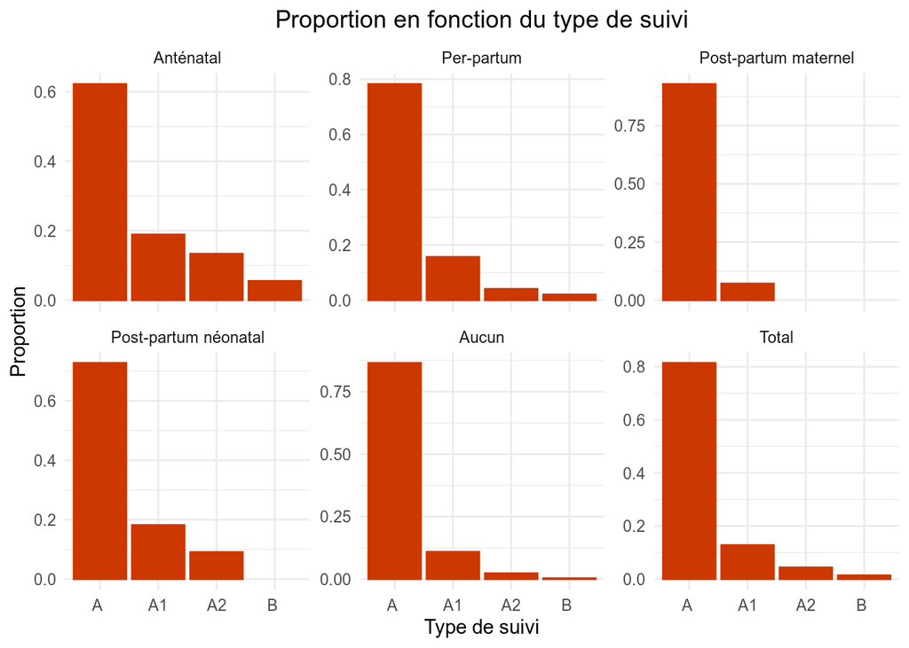

### 1.4.1 Antécédents - Population complète

| Antécédent | Nombre | Proportion |
| --- | --- | --- |
| Aucun | 1116 | 85.98 % |
| Autre | 108 | 8.32 % |
| Diabète | 22 | 1.69 % |
| Utérus cicatriciel | 21 | 1.62 % |
| Siège | 17 | 1.31 % |
| Hypertension | 7 | 0.54 % |
| Malformation | 6 | 0.46 % |
| Jumeaux | 1 | 0.08 % |

### 1.4.2 Lien entre Utérus cicatriciel et transfert

On souhaite procéder à un test du $\chi^2$ d’indépendance entre les variables binaires **Utérus cicatriciel** (1 si l’utérus est cicatriciel, 0 sinon) et **transfert** (1 si la femme a fait l’objet d’un transfert anténatal, perpartum ou post-partum, 0 sinon). L’hypothèse nulle est $H_0$ : les deux variables sont indépendantes. On présente ci-dessous le tableau des effectifs par modalités :

|  | 0 | 1 |
| --- | --- | --- |
| 0 | 894 | 383 |
| 1 | 15 | 6 |

Le nombre de femmes présentant un utérus cicatriciel et ayant fait l’objet d’un transfert est faible mais reste au-dessus des standards pour le test effectué (effectifs $\geq$ 5).

```
##
##  Pearson's Chi-squared test with Yates' continuity correction
##
## data:  .
## X-squared = 0.60645, df = 1, p-value = 0.4361
```

La p-value est égale à 0.4361278. On ne rejette pas l’hypothèse d’indépendance $H_0$ au seuil de signification 5%. Le test ne permet pas de conclure qu’il existe une dépendance statistique entre les deux variables étudiées.

### 1.4.3 Lien entre Utérus cicatriciel et hémorragie

On souhaite procéder à un test du $\chi^2$ d’indépendance entre les variables binaires **Utérus cicatriciel** (1 si l’utérus est cicatriciel, 0 sinon) et **hémorragie** (1 si des pertes sanguines de plus de 500 cl ont été observées, 0 sinon). L’hypothèse nulle est $H_0$ : les deux variables sont indépendantes. On présente ci-dessous le tableau des effectifs par modalités :

|  | 0 | 1 |
| --- | --- | --- |
| 0 | 879 | 44 |
| 1 | 14 | 1 |

Le nombre de femmes présentant un utérus cicatriciel et ayant fait une hémorragie (effectifs < 5) ne permet pas de d’effectuer le test d’indépendance dans des conditions satisfaisantes.

# 2 Transfert anténatal

## 2.1 Lien entre transfert anténatal, âge et parité

On effectue une régression logistique où la variable à expliquer est le transfert anténatal (1 : transfert / 0 : pas de transfert), et les variables explicatives sont l’âge de la mère et la parité.

```
##
## Call:
## glm(formula = transfert_antenatal ~ age_mere + parite, family = "binomial",
##     data = don_transfert_antenatal_age_parite)
##
## Deviance Residuals:
##     Min       1Q   Median       3Q      Max
## -0.7923  -0.6316  -0.5915  -0.5282   2.2197
##
## Coefficients:
##             Estimate Std. Error z value  Pr(>|z|)
## (Intercept) -2.33043    0.55855  -4.172 0.0000302 ***
## age_mere     0.03356    0.01788   1.878    0.0604 .
## parite      -0.17751    0.07034  -2.524    0.0116 *
## ---
## Signif. codes:  0 '***' 0.001 '**' 0.01 '*' 0.05 '.' 0.1 ' ' 1
##
## (Dispersion parameter for binomial family taken to be 1)
##
##     Null deviance: 1171.8  on 1297  degrees of freedom
## Residual deviance: 1163.8  on 1295  degrees of freedom
## AIC: 1169.8
##
## Number of Fisher Scoring iterations: 4
```

Les résidus présentent une symétrie correcte. On effectue un test de vraissemblance (LRT) pour estimer la significativité statistiques des variables explicatives car ce test est plus robuste que le test de Wald dont les résultats sont disponibles ci-dessus.

```
## Analysis of Deviance Table
##
## Model: binomial, link: logit
##
## Response: transfert_antenatal
##
## Terms added sequentially (first to last)
##
##
##          Df Deviance Resid. Df Resid. Dev Pr(>Chi)
## NULL                      1297     1171.8
## age_mere  1   1.1088      1296     1170.7  0.29234
## parite    1   6.9062      1295     1163.8  0.00859 **
## ---
## Signif. codes:  0 '***' 0.001 '**' 0.01 '*' 0.05 '.' 0.1 ' ' 1
```

D’après le test LRT, l’âge de la mère n’est pas une variable statistiquement significative dans le cadre de la modélisation du transfert anténatal par régression logistique : la p-value est élevée et la déviance très faible. De plus le coefficient associé à l’âge de la mère est proche de 0. En revanche la parité est statistiquement significative avec une p-value inférieure à 1% et une déviance importante. Le coefficient associé est négatif.

- L’**âge de la mère** ne semble pas être lié au transfert anténatal
- Statistiquement, la **parité** a une influence claire sur le transfert anténatal : plus la parité est élevée, moins la probabilité de transfert est importante.

| Parité | Nombre | Taux de transfert anténatal |
| --- | --- | --- |
| Multipares | 828 | 13.53 % |
| Primipares | 470 | 22.34 % |

## 2.2 Causes de transfert anténatal

| Cause de transfert anténatal | Nombre | Proportion |
| --- | --- | --- |
| Autre | 123 | 56.68 % |
| Grossesse prolongée | 38 | 17.51 % |
| Rupture de la poche des eaux sans mise en travail | 24 | 11.06 % |
| Accouchement prématuré | 15 | 6.91 % |
| Hypertension | 7 | 3.23 % |
| Portage Streptocoque B | 6 | 2.76 % |
| Diabète | 4 | 1.84 % |

# 3 Travail

Dans cette partie, on exclut la population des femmes ayant fait l’objet d’un transfert anténatal.

## 3.1 Entrée en travail

| Entrée en travail | Nombre | Proportion |
| --- | --- | --- |
| Induite | 66 | 6.11 % |
| Spontanée | 1015 | 93.89 % |

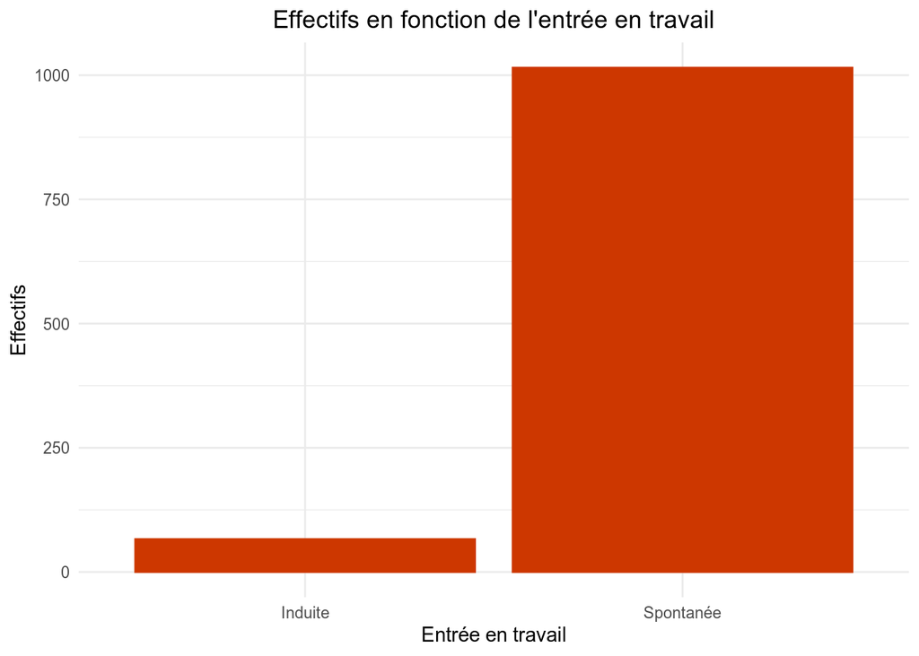

## 3.2 Phases latente / active

| Phase de travail | Durée moyenne (h) | Durée minimale (h) | Durée maximale (h) | Écart-type (h) |
| --- | --- | --- | --- | --- |
| Active | 3.80 | 0 | 23 | 3.23 |
| Latente | 6.79 | 0 | 72 | 8.18 |

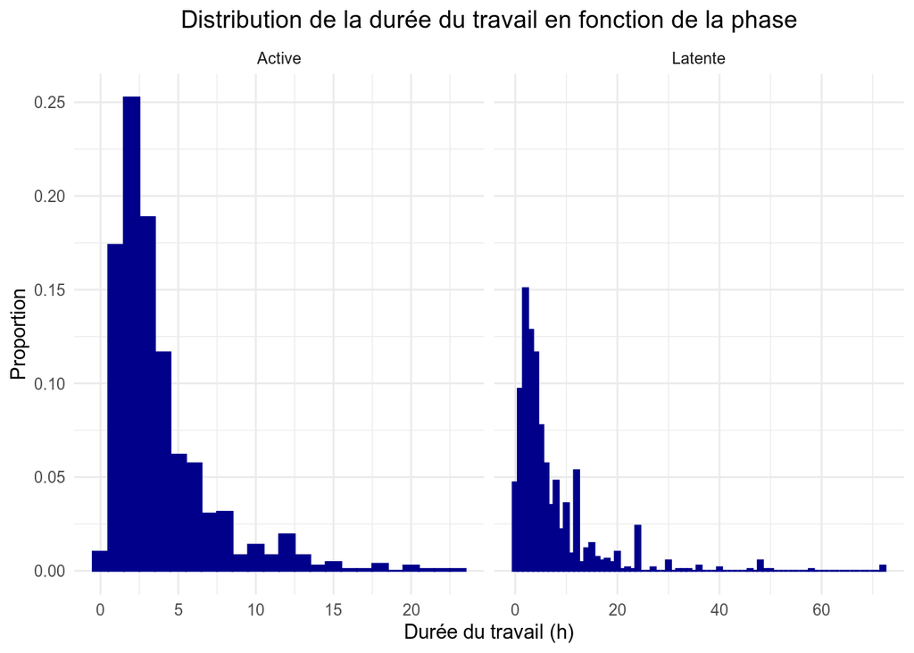

## 3.3 Rupture de la poche des eaux

| Nombre | Proportion | Rupture | Durée travail - Min (h) | Durée travail - Max (h) | Durée travail - Moy. (h) | Durée travail - E.T. (h) |
| --- | --- | --- | --- | --- | --- | --- |
| 62 | 5.74 % | Artificielle | 4 | 84 | 23.27 | 16.91 |
| 1019 | 94.26 % | Spontanée | 0 | 78 | 9.81 | 8.98 |

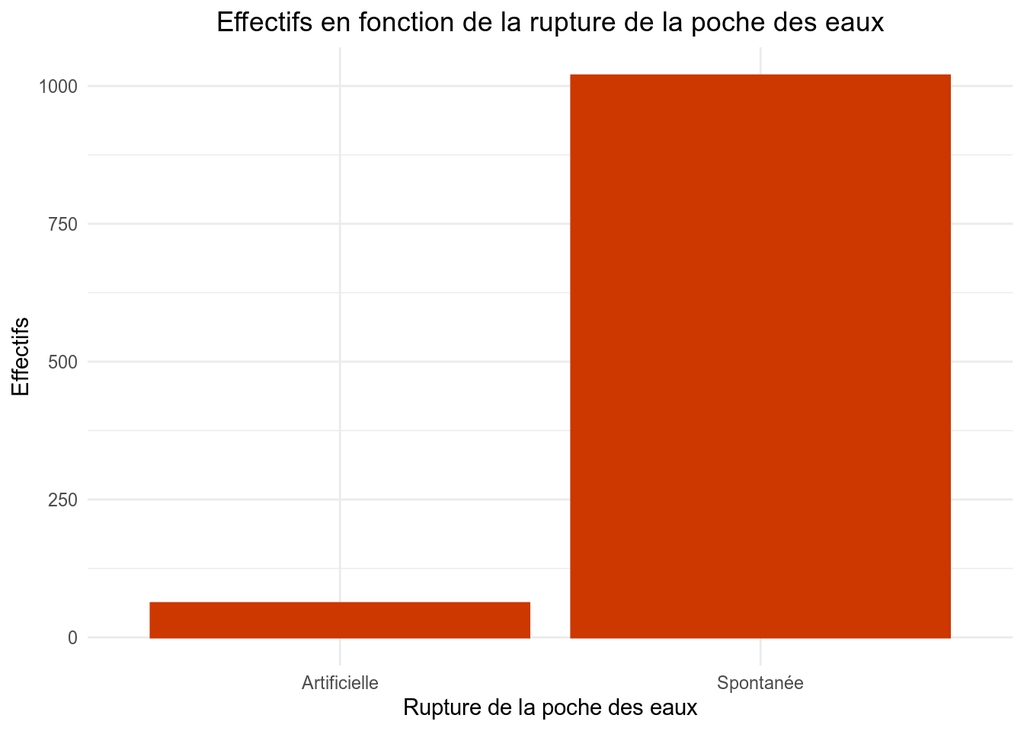

## 3.4 Durée d’ouverture de l’oeuf

| Durée d’ouverture de l’oeuf | Nombre | Proportion |
| --- | --- | --- |
| Inférieure à 12h | 690 | 63.83 % |
| Rupture de la poche des eaux à dilatation complète | 194 | 17.95 % |
| Bébé né coiffé | 80 | 7.4 % |
| Entre 12h et 24h | 78 | 7.22 % |
| Supérieure à 24h | 39 | 3.61 % |

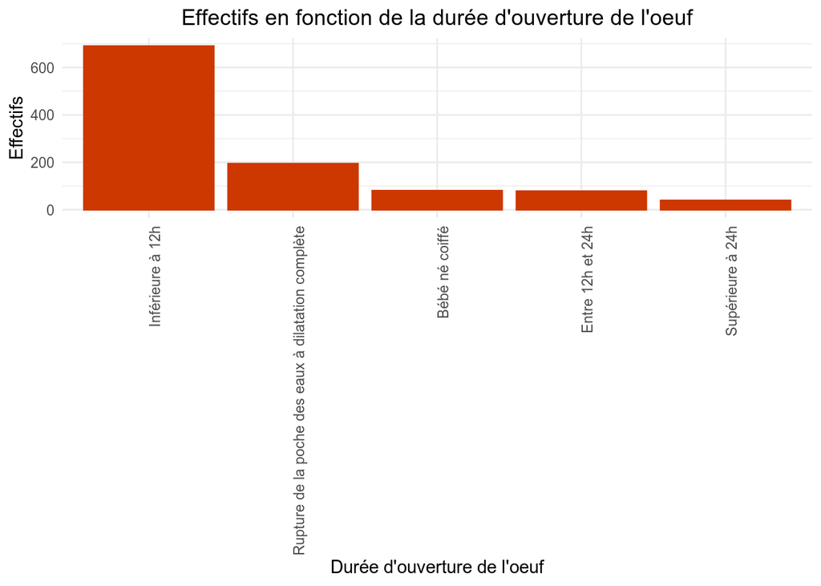

## 3.5 Couleur du liquide amniotique

### 3.5.1 Distribution

| Couleur du liquide amniotique | Nombre | Proportion |
| --- | --- | --- |
| Clair | 999 | 92.41 % |
| Teinté fluide | 47 | 4.35 % |
| Teinté méconial | 23 | 2.13 % |
| Autre ( sanglant, citrin … ) | 12 | 1.11 % |

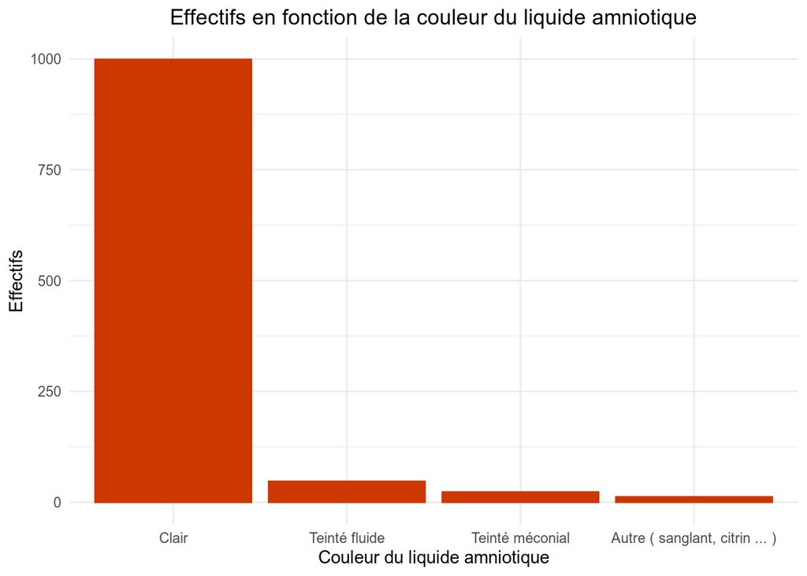

### 3.5.2 Liquide amniotique / transfert

#### 3.5.2.1 Effectifs

| Couleur du liquide amniotique | Transfert per-partum OU post-partum | Nombre | Proportion |
| --- | --- | --- | --- |
| Clair | Non | 856 | 85.69 % |
| Clair | Oui | 143 | 14.31 % |
| Teinté fluide | Non | 31 | 65.96 % |
| Teinté fluide | Oui | 16 | 34.04 % |
| Teinté méconial | Non | 15 | 65.22 % |
| Teinté méconial | Oui | 8 | 34.78 % |
| Autre ( sanglant, citrin … ) | Non | 7 | 58.33 % |
| Autre ( sanglant, citrin … ) | Oui | 5 | 41.67 % |

#### 3.5.2.2 Risque relatif de transfert per-partum ou post-partum des liquides amniotiques teintés par rapport aux liquides amniotiques clairs

RR = 2.38 et IC95%(RR) = [1.66;3.4]

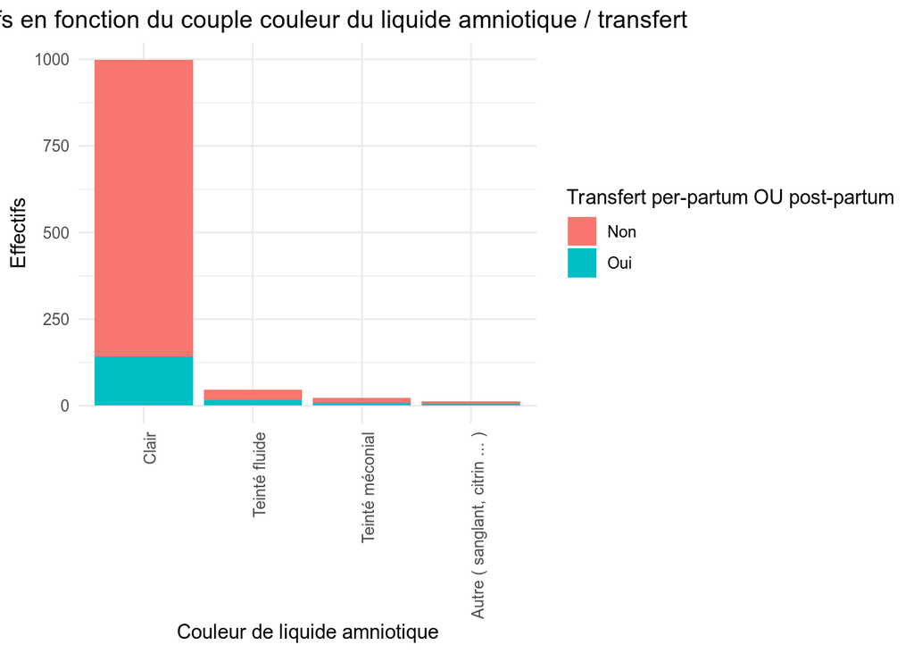

#### 3.5.2.3 Indépendance

##### 3.5.2.3.1 Premier test

On procède à un test du $\chi^2$ d’indépendance entre les deux variables **Couleur du liquide amniotique** et **transfert per-partum OU post-partum**. Dans cette partie, on exclut les individus tels que **Couleur du liquide amniotique** = *Autre ( sanglant, citrin … )* car les effectifs associés sont faibles. L’hypothèse nulle est $H_0$ : les deux variables sont indépendantes.

```
##
##  Pearson's Chi-squared test
##
## data:  don_la_transfert_chi2
## X-squared = 19.8, df = 2, p-value = 0.00005016
```

La p-value est très faible, égale à 0.0000502. On rejette l’hypothèse d’indépendance $H_0$ au seuil de signification 1%. On peut néanmoins remarquer que certains couples de modalités sont faiblement représentées dans l’échantillon de test, c’est le cas notamment du couple ( **Couleur du liquide amniotique** = *Teinté méconial*, **Transfert per-partum OU post-partum** = *Oui* ) avec seulement 8 individus.

Ci-dessous, on fusionne les modalités *Teinté fluide* et *Teinté méconial* en une seule modalité : *Teinté*.

##### 3.5.2.3.2 Deuxième test

On présente ci-dessous les effectifs avec les variables remaniées.

| Couleur du liquide amniotique | Transfert per-partum OU post-partum | Nombre | Proportion |
| --- | --- | --- | --- |
| Clair | Non | 856 | 85.69 % |
| Clair | Oui | 143 | 14.31 % |
| Teinté | Non | 46 | 65.71 % |
| Teinté | Oui | 24 | 34.29 % |

```
##
##  Pearson's Chi-squared test with Yates' continuity correction
##
## data:  .
## X-squared = 18.308, df = 1, p-value = 0.00001879
```

À nouveau, la p-value est très faible égale à 0.0000188. On rejette l’hypothèse d’indépendance $H_0$ au seuil de signification 1%.

La **couleur du liquide amniotique** et le **transfert per-partum ou post-partum** sont deux variables statistiquement **dépendantes**.

## 3.6 Présentations

### 3.6.1 Effectifs

| Présentation | Nombre | Proportion |
| --- | --- | --- |
| OP | 1014 | 93.8 % |
| OS | 61 | 5.64 % |
| Front | 2 | 0.19 % |
| Siège | 2 | 0.19 % |
| OP, Front | 1 | 0.09 % |
| OP, OS | 1 | 0.09 % |

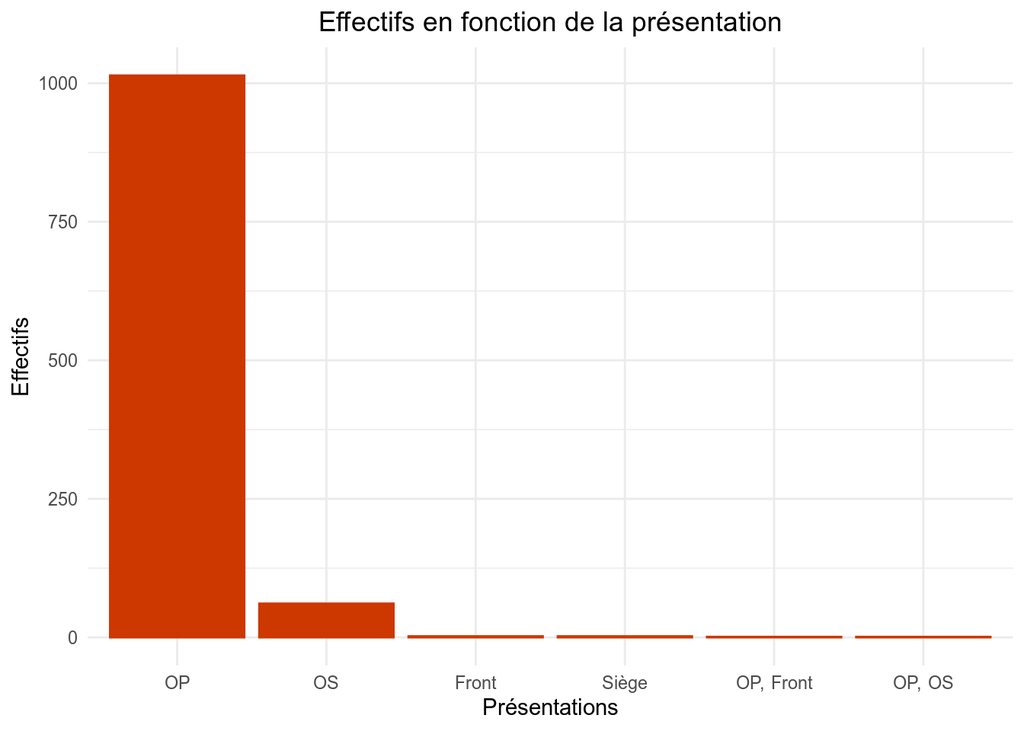

### 3.6.2 Siège

| Présentation | Nombre | Dont transfert per-partum |
| --- | --- | --- |
| Siège | 2 | 2 |

Deux bébés se sont présentés par le siège. Ils ont tous les deux fait l’objet d’un transfert per-partum.

### 3.6.3 Présentation et transfert : effectifs et lien statistique

On souhaite procéder à un test du $\chi^2$ d’indépendance entre les variables **Présentation**, **Type de transfert** (per-partum / post-partum) et **Transfert**. On présente ci-dessous le tableau des effectifs par modalités :

| presentation | type_transfert | transfert | Freq |
| --- | --- | --- | --- |
| Front | transfert_perpartum | 0 | 0 |
| OP | transfert_perpartum | 0 | 894 |
| OP, Front | transfert_perpartum | 0 | 1 |
| OP, OS | transfert_perpartum | 0 | 0 |
| OS | transfert_perpartum | 0 | 39 |
| Siège | transfert_perpartum | 0 | 0 |
| Front | transfert_post_partum | 0 | 2 |
| OP | transfert_post_partum | 0 | 989 |
| OP, Front | transfert_post_partum | 0 | 1 |
| OP, OS | transfert_post_partum | 0 | 1 |
| OS | transfert_post_partum | 0 | 61 |
| Siège | transfert_post_partum | 0 | 2 |
| Front | transfert_perpartum | 1 | 2 |
| OP | transfert_perpartum | 1 | 120 |
| OP, Front | transfert_perpartum | 1 | 0 |
| OP, OS | transfert_perpartum | 1 | 1 |
| OS | transfert_perpartum | 1 | 22 |
| Siège | transfert_perpartum | 1 | 2 |
| Front | transfert_post_partum | 1 | 0 |
| OP | transfert_post_partum | 1 | 25 |
| OP, Front | transfert_post_partum | 1 | 0 |
| OP, OS | transfert_post_partum | 1 | 0 |
| OS | transfert_post_partum | 1 | 0 |
| Siège | transfert_post_partum | 1 | 0 |

Un trop grand nombre de couples de modalités sont nulles ou négligeables en effectif. On remanie le jeu de données de la façon suivante :  
* On ne considère que les modalités *OP* et *OS* pour la variable **Présentation** * On considère la variable binaire **Transfert per-partum ou post-partum**

|  | Non | Oui |
| --- | --- | --- |
| OP | 869 | 145 |
| OS | 39 | 22 |

Dans ces conditions, on peut procéder à un test du $\chi^2$ d’indépendance entre les deux variables considérées. L’hypothèse nulle est $H_0$ : les deux variables sont indépendantes.

```
##
##  Pearson's Chi-squared test with Yates' continuity correction
##
## data:  .
## X-squared = 19.148, df = 1, p-value = 0.00001209
```

La p-value est très faible, égale à 0.0000121. On rejette l’hypothèse d’indépendance $H_0$ au seuil de signification 1%. Les variables **Présentation** et **Transfert per-partum ou post-partum**, telles qu’elles sont présentées ci-dessus, sont statistiquement dépendantes.

RR = 2.5 et IC95%(RR) = [1.73;3.61]

# 4 Accouchement des femmes non-transférées

Dans cette partie, on exclut la population des femmes ayant fait l’objet d’un transfert anténatal ou d’un transfert perpartum.

## 4.1 Position d’accouchement

### 4.1.1 Effectifs

| Position d’accouchement | Nombre | Proportion |
| --- | --- | --- |
| À genoux / À quatre pattes | 461 | 49.36 % |
| Accroupie | 106 | 11.35 % |
| Décubitus latéral | 104 | 11.13 % |
| Assise | 94 | 10.06 % |
| Debout | 69 | 7.39 % |
| Semi-assise | 57 | 6.1 % |
| Décubitus dorsal | 27 | 2.89 % |
| Position gynécologique | 16 | 1.71 % |

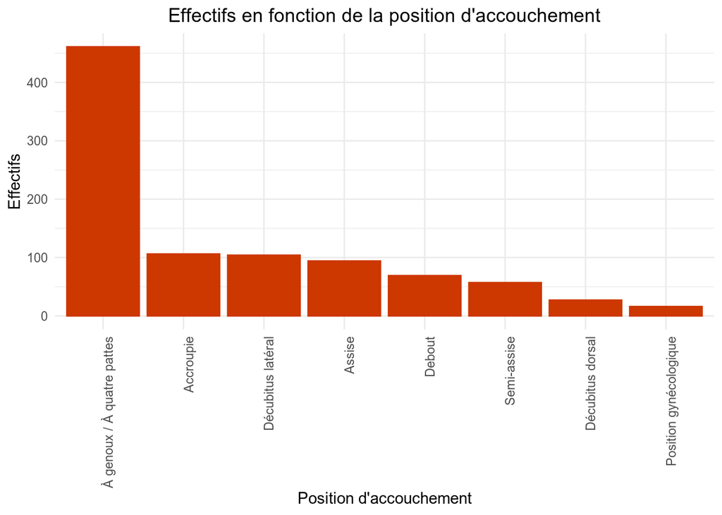

### 4.1.2 Position d’accouchement et état du périnée

| Position d’accouchement | État du périnée | Nombre | Proportion |
| --- | --- | --- | --- |
| À genoux / À quatre pattes | 1° degré : peau, muqueuse vaginale | 136 | 29.5 % |
| À genoux / À quatre pattes | Degré 2 / Degré 3 / Épisiotomie | 26 | 5.64 % |
| À genoux / À quatre pattes | Intact | 299 | 64.86 % |
| Accroupie | 1° degré : peau, muqueuse vaginale | 24 | 22.64 % |
| Accroupie | Degré 2 / Degré 3 / Épisiotomie | 12 | 11.32 % |
| Accroupie | Intact | 70 | 66.04 % |
| Assise / Semi-assise | 1° degré : peau, muqueuse vaginale | 47 | 31.13 % |
| Assise / Semi-assise | Degré 2 / Degré 3 / Épisiotomie | 7 | 4.64 % |
| Assise / Semi-assise | Intact | 97 | 64.24 % |
| Debout | 1° degré : peau, muqueuse vaginale | 16 | 23.19 % |
| Debout | Degré 2 / Degré 3 / Épisiotomie | 7 | 10.14 % |
| Debout | Intact | 46 | 66.67 % |
| Décubitus latéral / dorsal | 1° degré : peau, muqueuse vaginale | 28 | 21.37 % |
| Décubitus latéral / dorsal | Degré 2 / Degré 3 / Épisiotomie | 12 | 9.16 % |
| Décubitus latéral / dorsal | Intact | 91 | 69.47 % |
| Position gynécologique | 1° degré : peau, muqueuse vaginale | 2 | 12.5 % |
| Position gynécologique | Degré 2 / Degré 3 / Épisiotomie | 1 | 6.25 % |
| Position gynécologique | Intact | 13 | 81.25 % |

Il faut exclure la *position gynécologique* par manque d’individus. On peut néanmoins noter que la proportion de périnée intact est la plus élevée pour cette position. Cette observation est toutefois à nuancer en prenant en compte le faible nombre d’individus concernés.

```
##
##  Pearson's Chi-squared test
##
## data:  don_position_perinee_chi2
## X-squared = 12.095, df = 8, p-value = 0.147
```

La p-value est nettement supérieure à 0.05, égale à 0.1470004. On ne rejette pas l’hypothèse d’indépendance au seuil de 5 %. Les variables de *position d’accouchement* et d’*état du périnée* apparaissent donc statistiquement indépendantes.

## 4.2 Accouchement dans l’eau

### 4.2.1 Effectifs

| Accouchement dans l’eau | Nombre | Proportion |
| --- | --- | --- |
| Non | 721 | 77.19 % |
| Oui | 213 | 22.81 % |

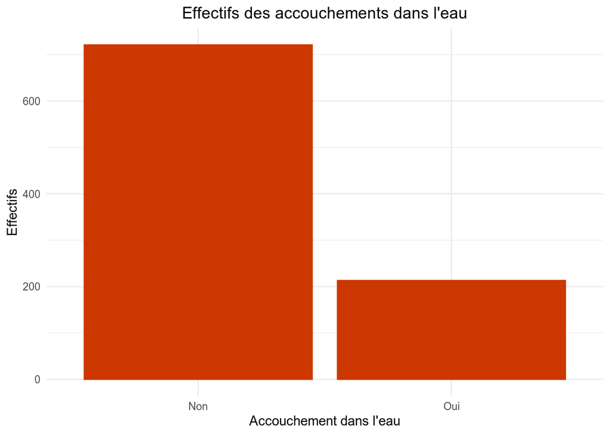

### 4.2.2 Accouchement dans l’eau et réa bébé

On procède à un test du $\chi^2$ d’indépendance entre les deux variables **Accouchement dans l’eau** et **Réanimation du bébé**, égale à 1 dans le cas où des gestes de réanimation ont été administrés (aspiration, stimulation, ventilation ou médication) et 0 si aucun geste de réanimation n’a été nécessaire. L’hypothèse nulle est $H_0$ : les deux variables sont indépendantes. On présente ci-dessous le tableau des effectifs, puis les résultats du test d’indépendance.

| Accouchement dans l’eau | Réanimation | Nombre | Proportion |
| --- | --- | --- | --- |
| Non | 0 | 683 | 94.73 % |
| Non | 1 | 38 | 5.27 % |
| Oui | 0 | 202 | 94.84 % |
| Oui | 1 | 11 | 5.16 % |

```
##
##  Pearson's Chi-squared test with Yates' continuity correction
##
## data:  don_accouchement_eau_rea_chi2
## X-squared = 3.728e-28, df = 1, p-value = 1
```

La p-value est importante, égale à 1. On ne rejette pas l’hypothèse d’indépendance $H_0$ au seuil de signification de 5%. Il ne semble y a voir aucun lien de dépendance entre l’accouchement dans l’eau et l’administration de gestes de réanimation au bébé.

### 4.2.3 Accouchement dans l’eau et état du périnée

| Accouchement dans l’eau | État du périnée | Nombre | Proportion |
| --- | --- | --- | --- |
| Non | 1° degré : peau, muqueuse vaginale | 185 | 25.66 % |
| Non | Degré 2 / Degré 3 / Épisiotomie | 50 | 6.93 % |
| Non | Intact | 486 | 67.41 % |
| Oui | 1° degré : peau, muqueuse vaginale | 68 | 31.92 % |
| Oui | Degré 2 / Degré 3 / Épisiotomie | 15 | 7.04 % |
| Oui | Intact | 130 | 61.03 % |

```
##
##  Pearson's Chi-squared test
##
## data:  don_accouchement_eau_perinee_chi2
## X-squared = 3.3988, df = 2, p-value = 0.1828
```

La p-value est importante, égale à 0.1827939. On ne rejette pas l’hypothèse d’indépendance $H_0$ au seuil de signification 1%, ni même de 5%. On ne peut affirmer qu’il existe un lien statistique entre l’accouchement dans l’eau et l’état du périnée avec les données dont nous disposons.

### 4.2.4 Accouchement dans l’eau et tb de la délivrance

On souhaite étudier le lien entre les deux variables **Accouchement dans l’eau** et **Délivrance** *Naturelle complète* ou *Naturelle incomplète / Dirigée complète / Artificielle*. On présente ci-dessous le tableau des effectifs, puis les résultats du test d’indépendance.

| Accouchement dans l’eau | Délivrance | Nombre | Proportion |
| --- | --- | --- | --- |
| Non | Naturelle complète | 700 | 97.09 % |
| Non | Naturelle incomplète / Dirigée complète / Artificielle | 21 | 2.91 % |
| Oui | Naturelle complète | 213 | 100 % |

Les conditions du test du $\chi^2$ d’indépendance ne sont pas satisfaites puisque conditionnellement à un accouchement effectué dans l’eau, l’intégralité des délivrances ont été naturelles complètes. Néanmoins, ce résultat remarquable suggère un éventuel lien entre accouchement dans l’eau et délivrance naturelle complète, compte tenu de l’importance des effectifs.

### 4.2.5 Accouchement dans l’eau et pertes sanguines

On procède à un test du $\chi^2$ d’indépendance entre les deux variables **Accouchement dans l’eau** et **Hémorragie**, caractérisée par des pertes sangines supérieures à 500 cl. L’hypothèse nulle est $H_0$ : les deux variables sont indépendantes. On présente ci-dessous le tableau des effectifs, puis les résultats du test d’indépendance.

| Accouchement dans l’eau | Hémorragie | Nombre | Proportion |
| --- | --- | --- | --- |
| Non | 0 | 687 | 95.28 % |
| Non | 1 | 34 | 4.72 % |
| Oui | 0 | 203 | 95.31 % |
| Oui | 1 | 10 | 4.69 % |

```
##
##  Pearson's Chi-squared test with Yates' continuity correction
##
## data:  don_accouchement_eau_hemo_chi2
## X-squared = 2.0859e-30, df = 1, p-value = 1
```

La p-value est très élevée, égale à 1. Il est très probable qu’il n’y ait aucun lien de dépendance entre l’accouchement dans l’eau et la survenue d’une hémorragie.

## 4.3 Durée d’expulsion

### 4.3.1 Caractéristiques / Distribution

| Durée moyenne (min) | Durée minimale (min) | Durée maximale (min) | Écart-type (min) |
| --- | --- | --- | --- |
| 17.88 | 0 | 300 | 21.67 |

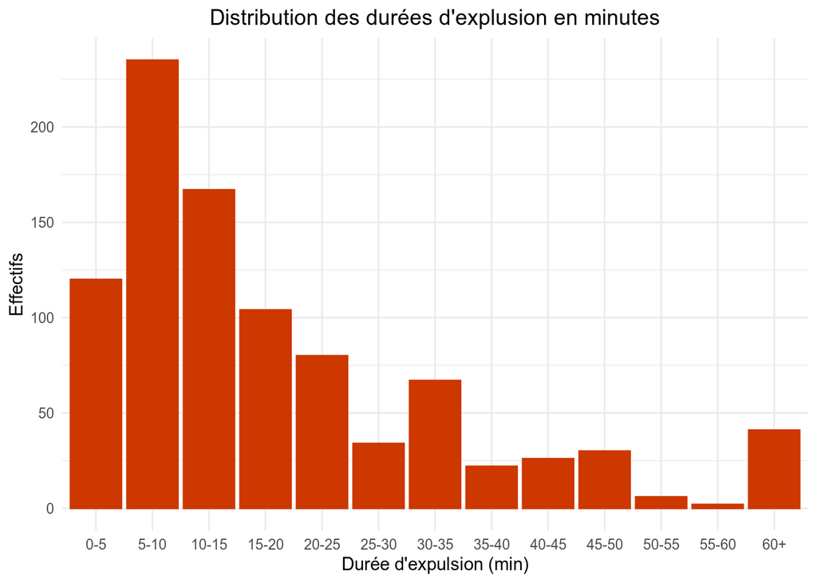

### 4.3.2 Durée d’expulsion inférieure à 30 minutes

En particulier, on peut noter que pour 804 femmes (86.08 % ayant effectivement accouché à domicile), la durée d’expulsion a été inférieure ou égale à 30 minutes.

### 4.3.3 Durée d’expulsion et poids du bébé

Le coefficient de corrélation entre la durée d’expulsion et le poids du bébé est égal à -0.06. Il n’y a donc aucun lien linéaire entre ces deux variables.

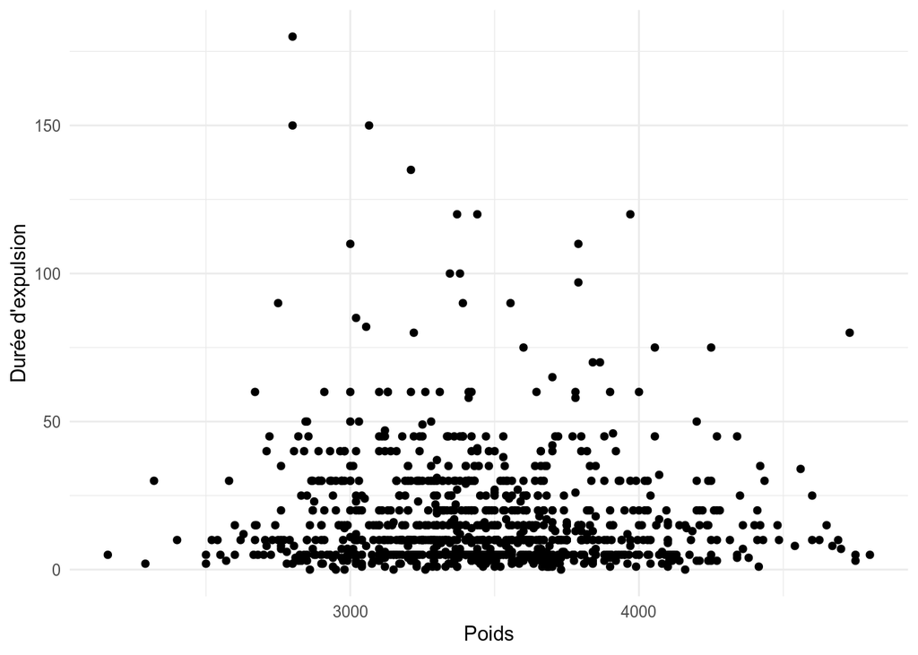

Le “scatter plot” des deux variables considérées ne permet pas d’identifier un éventuel lien non-linéaire.

### 4.3.4 Durée d’expulsion et position d’accouchement

On effectue une analyse de variance de la durée d’expulsion en fonction de la position d’accouchement.

```
## Analysis of Variance Table
##
## Response: duree_expulsion
##                        Df Sum Sq Mean Sq F value   Pr(>F)
## position_accouchement   5   8955 1790.97  3.8727 0.001768 **
## Residuals             928 429169  462.47
## ---
## Signif. codes:  0 '***' 0.001 '**' 0.01 '*' 0.05 '.' 0.1 ' ' 1
```

L’analyse de variance indique une interaction statistiquement significative entre la position d’accouchement et la durée d’expulsion. La satisfaction des hypothèses d’indépendance, de normalité des résidus et d’homoscédasticité doivent toutefois être vérifiées par les données. On donne ci-dessous les durées d’expulsion médiane et moyenne en fonction de la position :

[output not shown]

La durée d’expulsion paraît beaucoup plus importante en position gynécologique. Le nombre d’individus est néanmoins très inférieur aux effectifs des autres groupes de position.

## 4.4 Hands on / Hands off

### 4.4.1 Effectifs

| Hands | Nombre | Proportion |
| --- | --- | --- |
| Hands off / 2 temps | 523 | 56 % |
| Hands off / 1 temps | 285 | 30.51 % |
| Hands on | 105 | 11.24 % |
| Donnée indisponible | 21 | 2.25 % |

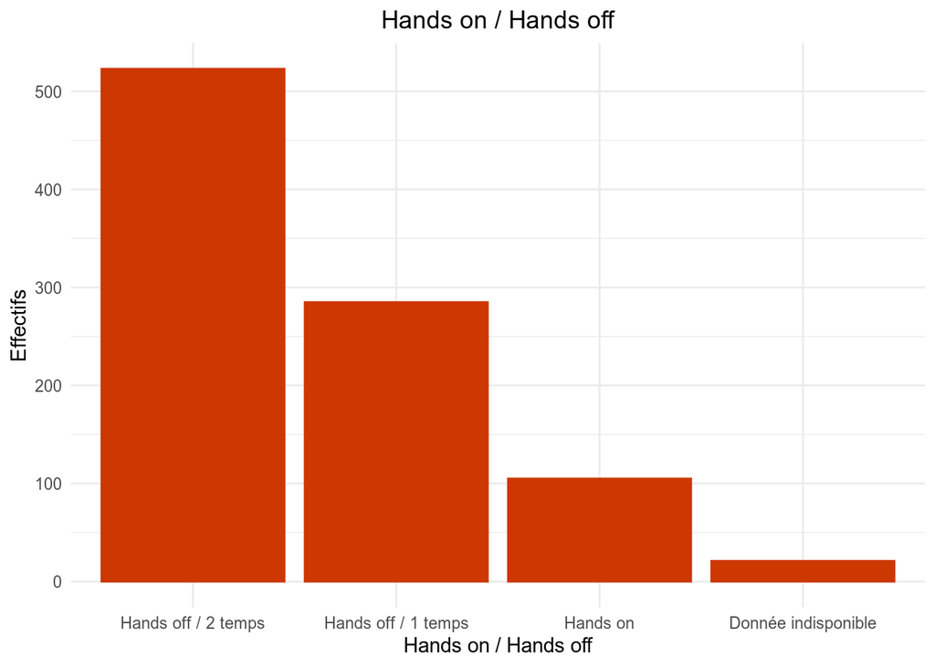

### 4.4.2 Hands On-Off / État du périnée

| Hands | État du périnée | Nombre | Proportion |
| --- | --- | --- | --- |
| Hands off / 1 temps | Degré 1 | 71 | 24.91 % |
| Hands off / 1 temps | Degré 2 / Degré 3 / Épisiotomie | 12 | 4.21 % |
| Hands off / 1 temps | Intact | 202 | 70.88 % |
| Hands off / 2 temps | Degré 1 | 145 | 27.72 % |
| Hands off / 2 temps | Degré 2 / Degré 3 / Épisiotomie | 42 | 8.03 % |
| Hands off / 2 temps | Intact | 336 | 64.24 % |
| Hands on | Degré 1 | 31 | 29.52 % |
| Hands on | Degré 2 / Degré 3 / Épisiotomie | 10 | 9.52 % |
| Hands on | Intact | 64 | 60.95 % |

```
##
##  Pearson's Chi-squared test
##
## data:  don_hands_perinee_chi2
## X-squared = 7.3946, df = 4, p-value = 0.1164
```

La p-value égale à 0.1164466 ne permet pas de rejeter l’hypothèse d’indépendance $H_0$ au seuil de 5%. Ainsi, les données ne permettent d’établir une liaison entre les deux variables considérées.

## 4.5 Présence de la sage-feme

### 4.5.1 Effectifs

[output not shown]

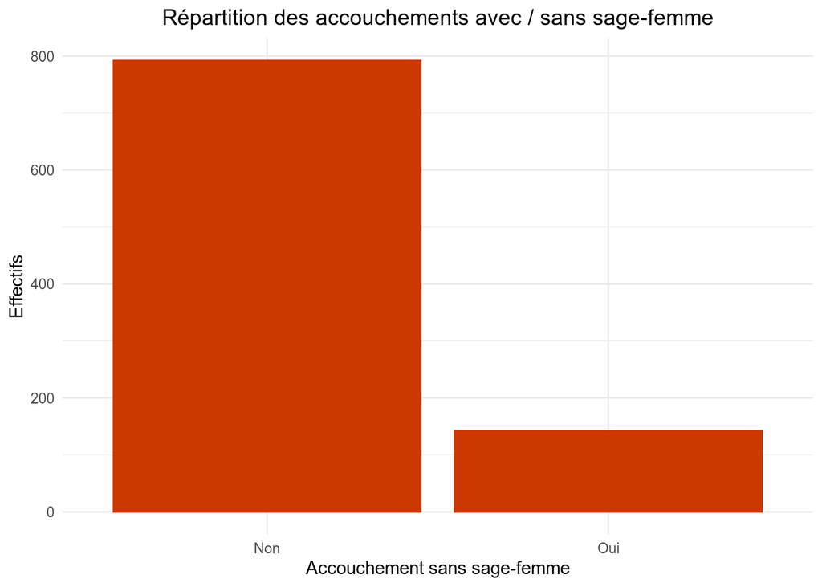

### 4.5.2 Accouchement avec ou sans sage-femme / Distance entre la maison et la sage-femme / Parité

On effectue une régression logistique où la variable à expliquer est l’accouchement avec sage-femme (1 : présence sage-femme / 0 : absence sage-femme), et les variables explicatives sont la distance entre la maison et la sage-femme ainsi que la parité.

```
##
## Call:
## glm(formula = sage_femme ~ distance_mere_sf + parite, family = "binomial",
##     data = don_sf_dist_par)
##
## Deviance Residuals:
##     Min       1Q   Median       3Q      Max
## -2.2226   0.4453   0.5119   0.5910   1.4444
##
## Coefficients:
##                   Estimate Std. Error z value  Pr(>|z|)
## (Intercept)       2.668777   0.219254  12.172   < 2e-16 ***
## distance_mere_sf -0.007529   0.002247  -3.351  0.000806 ***
## parite           -0.249583   0.063942  -3.903 0.0000949 ***
## ---
## Signif. codes:  0 '***' 0.001 '**' 0.01 '*' 0.05 '.' 0.1 ' ' 1
##
## (Dispersion parameter for binomial family taken to be 1)
##
##     Null deviance: 796.18  on 933  degrees of freedom
## Residual deviance: 770.67  on 931  degrees of freedom
## AIC: 776.67
##
## Number of Fisher Scoring iterations: 4
```

Les résidus présentent une symétrie correcte. On effectue un test de vraissemblance (LRT) pour estimer la significativité statistiques des variables explicatives car ce test est plus robuste que le test de Wald dont les résultats sont disponibles ci-dessus.

```
## Analysis of Deviance Table
##
## Model: binomial, link: logit
##
## Response: sage_femme
##
## Terms added sequentially (first to last)
##
##
##                  Df Deviance Resid. Df Resid. Dev  Pr(>Chi)
## NULL                               933     796.18
## distance_mere_sf  1   11.063       932     785.12 0.0008805 ***
## parite            1   14.447       931     770.67 0.0001442 ***
## ---
## Signif. codes:  0 '***' 0.001 '**' 0.01 '*' 0.05 '.' 0.1 ' ' 1
```

### 4.5.3 Risque relatif d’accouchement sans sage-femme des primipares par rapport aux multipares

RR = 0.27 et IC95%(RR) = [0.16;0.47]

# 5 Transfert per-partum parmi les femmes ayant débuté le travail à la maison (i.e pas de transfert anténatal)

## 5.1 Effectifs

| Transfert per-partum | Nombre | Proportion |
| --- | --- | --- |
| Non | 934 | 86.4 % |
| Oui | 147 | 13.6 % |

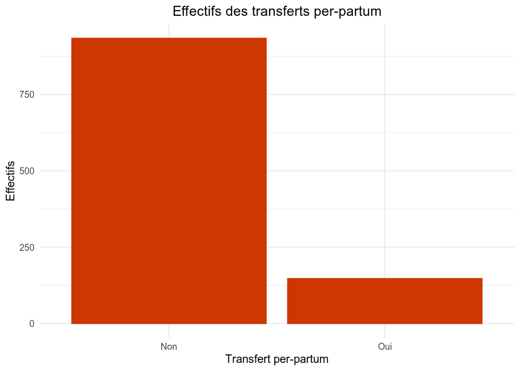

## 5.2 Lien entre tranfert per-partum et parité / âge

On effectue une régression logistique où la variable à expliquer est le transfert per-partum (1 : transfert / 0 : pas de transfert), et où les variables explicatives sont les suivantes : parité / âge de la mère.

```
##
## Call:
## glm(formula = transfert_perpartum ~ parite + age_mere, family = "binomial",
##     data = don_tpp_par_age_poids_dist)
##
## Deviance Residuals:
##     Min       1Q   Median       3Q      Max
## -1.2033  -0.5726  -0.4094  -0.1936   3.4609
##
## Coefficients:
##             Estimate Std. Error z value Pr(>|z|)
## (Intercept) -1.98102    0.69463  -2.852 0.004346 **
## parite      -1.30715    0.15202  -8.599  < 2e-16 ***
## age_mere     0.07442    0.02247   3.312 0.000927 ***
## ---
## Signif. codes:  0 '***' 0.001 '**' 0.01 '*' 0.05 '.' 0.1 ' ' 1
##
## (Dispersion parameter for binomial family taken to be 1)
##
##     Null deviance: 859.63  on 1080  degrees of freedom
## Residual deviance: 745.35  on 1078  degrees of freedom
## AIC: 751.35
##
## Number of Fisher Scoring iterations: 6
```

Les résidus sont relativement assymétriques, ce qui peut remettre en cause la pertinence du modèle. On effectue un test de vraissemblance (LRT) pour estimer la significativité statistiques des variables explicatives car ce test est plus robuste que le test de Wald dont les résultats sont disponibles ci-dessus.

```
## Analysis of Deviance Table
##
## Model: binomial, link: logit
##
## Response: transfert_perpartum
##
## Terms added sequentially (first to last)
##
##
##          Df Deviance Resid. Df Resid. Dev  Pr(>Chi)
## NULL                      1080     859.63
## parite    1  103.040      1079     756.59 < 2.2e-16 ***
## age_mere  1   11.237      1078     745.35  0.000802 ***
## ---
## Signif. codes:  0 '***' 0.001 '**' 0.01 '*' 0.05 '.' 0.1 ' ' 1
```

D’après le test LRT, la significativité statistique de la parité est particulièrement importante pour expliquer le transfert per partum. En effet la p-value associée est extrêmement faible et le coefficient associé (dans la régression) relativement important. Ainsi, une parité importante limite le risque de transfert perpartum L’âge de la mère est lui aussi une variable statistiquement significative. Son coefficient est toutefois proche de 0 dans la régression logistique. Ces conclusions sont à prendre avec réserve étant donnée l’assymétrie des résidus.

## 5.3 Causes de transfert

| Cause de transfert perpartum | Nombre |
| --- | --- |
| Non progression dilatation | 74 |
| Non progression présentation | 19 |
| Désir péridurale | 15 |
| Autre | 11 |
| Liquide amniotique teinté | 9 |
| Anomalie du Rythme Cardiaque Foetal | 5 |
| sage-femme indisponible | 5 |
| Présentation dystocique | 4 |
| Épuisement maternel | 3 |
| NA | 2 |

## 5.4 Modalités d’accouchement post-transfert

Cette partie concerne les femmes ayant début le travail à la maison, mais transférée avant l’accouchement.

| Modalité d’accouchement | Nombre | Proportion |
| --- | --- | --- |
| Accouchement par Voie Basse | 91 | 61.9 % |
| Aide instrumentale | 24 | 16.33 % |
| Césarienne | 24 | 16.33 % |
| NA | 8 | 5.44 % |

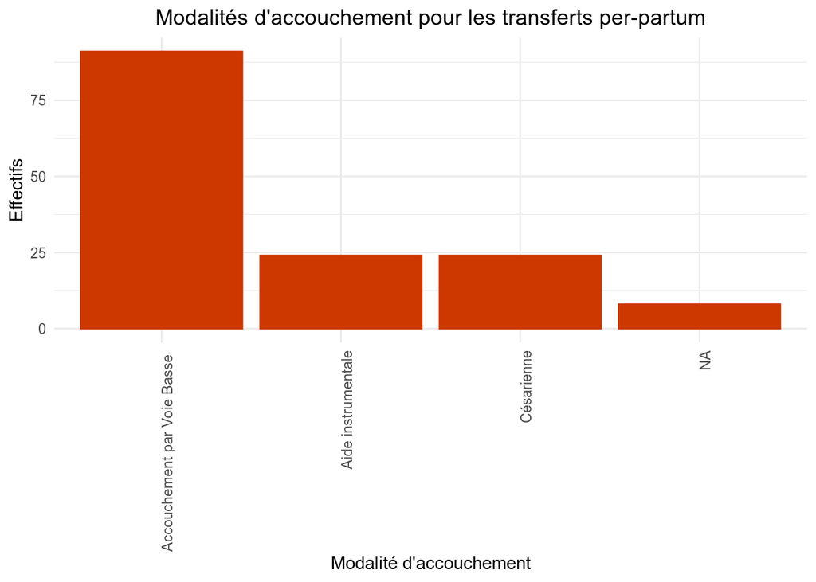

## 5.5 Modalités d’anesthésie post-transfert

| Modalité d’accouchement | Nombre | Proportion |
| --- | --- | --- |
| Anesthésie péridurale | 78 | 53.06 % |
| NA | 34 | 23.13 % |
| Aucune anesthésie | 21 | 14.29 % |
| Rachianesthésie | 8 | 5.44 % |
| Protoxyde d’azote | 6 | 4.08 % |

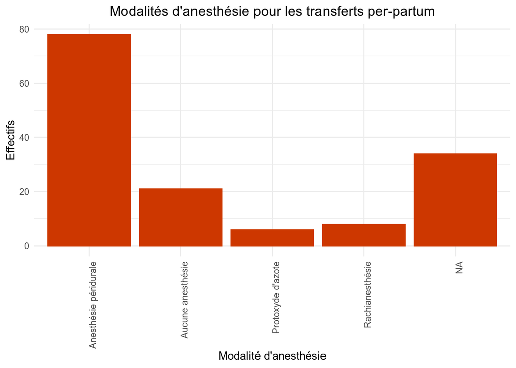

# 6 Délivrance pour les femmes n’ayant pas fait l’objet d’un transfert per-partum immédiat

On exclut ici les femmes transférées (transfert néonatal/perpartum/postpartum).

## 6.1 Effectifs

| Mode de délivrance | Nombre | Proportion |
| --- | --- | --- |
| Naturelle complète | 895 | 98.46 % |
| Naturelle incomplète | 8 | 0.88 % |
| Dirigée complète | 4 | 0.44 % |
| Artificielle | 2 | 0.22 % |

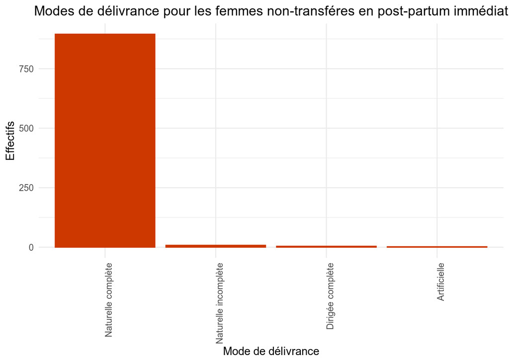

## 6.2 Délai entre naissance et délivrance

| Durée moyenne (min) | Durée minimale (min) | Durée maximale (min) | Écart-type (min) |
| --- | --- | --- | --- |
| 27.12 | 0 | 390 | 27.09 |

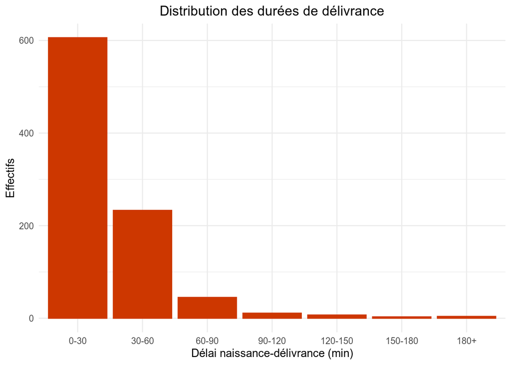

## 6.3 Pertes sanguines

### 6.3.1 Distribution

| Pertes sanguines | Nombre | Proportion |
| --- | --- | --- |
| Moins de 250 CC | 645 | 70.96 % |
| Moins de 500 cc | 230 | 25.3 % |
| Moins de 1000 CC | 30 | 3.3 % |
| Plus de 1000 cc | 4 | 0.44 % |

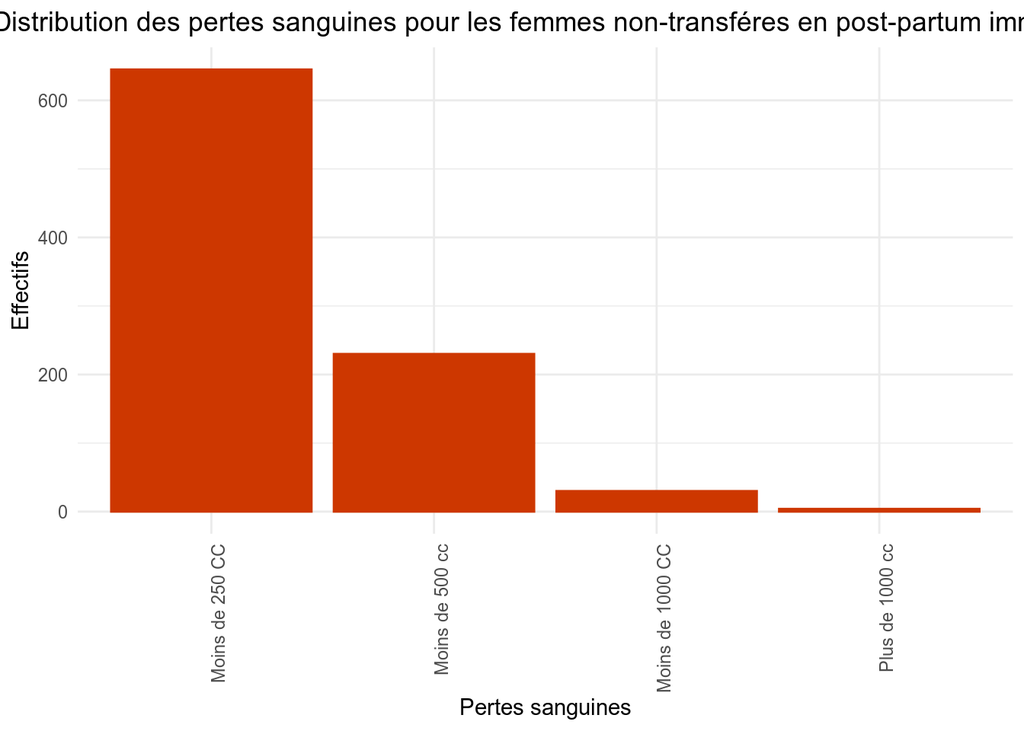

### 6.3.2 Liaison entre hémorragie et durée de la délivrance / Parité / Âge / Poids du bébé / Durée de la poussée

On effectue une régression logistique où la variable à expliquer est l’hémorragie (1 : hémorragie / 0 : pas d’hémorragie), et les variables explicatives sont celles listées ci-dessus. Un héomrragie est définie comme un volume de sang perdu supérieur à 500 cc.

```
##
## Call:
## glm(formula = hemo ~ delai_delivrance_naissance + parite + age_mere +
##     poids + duree_expulsion, family = "binomial", data = don_hemo_deliv_)
##
## Deviance Residuals:
##     Min       1Q   Median       3Q      Max
## -0.6068  -0.3036  -0.2475  -0.2013   3.0582
##
## Coefficients:
##                              Estimate Std. Error z value Pr(>|z|)
## (Intercept)                -7.5989548  2.0036380  -3.793 0.000149 ***
## delai_delivrance_naissance -0.0104423  0.0103882  -1.005 0.314797
## parite                     -0.3467919  0.2026190  -1.712 0.086980 .
## age_mere                    0.0284359  0.0433912   0.655 0.512250
## poids                       0.0012208  0.0004052   3.013 0.002590 **
## duree_expulsion             0.0051755  0.0064755   0.799 0.424150
## ---
## Signif. codes:  0 '***' 0.001 '**' 0.01 '*' 0.05 '.' 0.1 ' ' 1
##
## (Dispersion parameter for binomial family taken to be 1)
##
##     Null deviance: 290.08  on 907  degrees of freedom
## Residual deviance: 276.93  on 902  degrees of freedom
## AIC: 288.93
##
## Number of Fisher Scoring iterations: 6
```

Les résidus présentent une symétrie moyenne. On effectue un test de vraissemblance (LRT) pour estimer la significativité statistiques des variables explicatives car ce test est plus robuste que le test de Wald dont les résultats sont disponibles ci-dessus.

```
## Analysis of Deviance Table
##
## Model: binomial, link: logit
##
## Response: hemo
##
## Terms added sequentially (first to last)
##
##
##                            Df Deviance Resid. Df Resid. Dev Pr(>Chi)
## NULL                                         907     290.08
## delai_delivrance_naissance  1   1.0394       906     289.04 0.307966
## parite                      1   2.4768       905     286.57 0.115537
## age_mere                    1   0.3278       904     286.24 0.566962
## poids                       1   8.7710       903     277.47 0.003061 **
## duree_expulsion             1   0.5418       902     276.93 0.461695
## ---
## Signif. codes:  0 '***' 0.001 '**' 0.01 '*' 0.05 '.' 0.1 ' ' 1
```

### 6.3.3 Risque relatif d’hémorragie des primipares par rapport aux multipares

RR = 2.7 et IC95%(RR) = [1.52;4.79]